# Two Variables: Qualitative

Author

Shapple Kate Anne A. Nicolas

Published

November 12, 2026

# The Data

```r
# load packages
library(tidyverse)
library(knitr)
library(gtsummary)
library(ggstatsplot)
library(downlit)
library(broom)
library(here)
```

```r
# load the data
df <- read_csv(here("data", "My_Data.csv"))

df <- df |>
  mutate(
    stress_level = factor(
      stress_level,
      levels = c("Low", "Moderate", "High"),
      ordered = TRUE
    ),
    travel_mode = factor(
      travel_mode,
      levels = c(
        "Non-Motorized Transport (Walking / Biking)",
        "Motorized Transport (Tricycle / Jeepney / Motorcycle)"
      )
    )
  )|>
    select(
      stress_level,
      travel_mode,
    )
```

## NVSU_Student_Survey Set

- `travel_mode` Motorized Transport (Tricycle / Jeepney / Motorcycle), Non-Motorized Transport (Walking / Biking).
- `stress_level` Low, Moderate, High.

This data set provides information on the academic habits and lifestyle of undergraduate students at Nueva Vizcaya State University (NVSU), summarized according to daily travel time, weekly study hours, device usage, primary mode of transportation, exam stress level, and internet connection source.

The first 6 rows of the level data set are shown in Table 1.

```r
df |>
  head() |> # getting the first six rows of the data
  kable(
    col.names = c("Stress Level", "Mode of Transportation")
  ) # creating a table
```

Table 1: The first 6 observations of the data set.

| Stress Level | Mode of Transportation |
| --- | --- |
| Moderate | Motorized Transport (Tricycle / Jeepney / Motorcycle) |
| High | Non-Motorized Transport (Walking / Biking) |
| High | Motorized Transport (Tricycle / Jeepney / Motorcycle) |
| Moderate | Motorized Transport (Tricycle / Jeepney / Motorcycle) |
| Moderate | Non-Motorized Transport (Walking / Biking) |
| Low | Motorized Transport (Tricycle / Jeepney / Motorcycle) |

Descriptive Statistics

```r
#| label: tbl-summary
#| tbl-cap: "Summary statistics of `stress_level` when grouped according to `travel_mode`."
#| message: false

df |>

#  tbl_summary(
#    by = stress_level,
#    include = travel_mode
    tbl_cross(
      row = stress_level,
      col = travel_mode,
      percent = "column",
      margin = c("row", "column"),
      label = list(
        stress_level ~ "Level of Stress",
        travel_mode ~ "Mode of Transportation"
      )
  )
```

|  | Mode of Transportation Non-Motorized Transport (Walking / Biking) | Mode of Transportation Motorized Transport (Tricycle / Jeepney / Motorcycle) | Total |  |
| --- | --- | --- | --- | --- |
| Level of Stress |  |  |  |  |
| Low | 2 (7.7%) | 4 (9.5%) | 6 (8.8%) |  |
| Moderate | 13 (50%) | 20 (48%) | 33 (49%) |  |
| High | 11 (42%) | 18 (43%) | 29 (43%) |  |
| Total | 26 (100%) | 42 (100%) | 68 (100%) |  |

# Hypothesis Testing

## Research Question

Does students’ mode of transportation affect their level of stress?

## Hypothesis and Test Statistics

- $H_0:p_{Travel\,Mode}-p_{Stress\,Level}=0$; Students’ mode of transportation and their level of stress are independent (no association).
- $H_a:p_{Travel\,Mode}-p_{Stress\,Level}\ne0$; Students’ mode of transportation and their level of stress are dependent (associated).
- Significance level, $\alpha=5\%\,\text{or p-value}\,\le\,.05$.
- **Pearson’s** $\chi^2$-test of independence
- Independence.
- Expected counts: Not all expected counts are $\lt5$ (the ‘Low’ stress category expected counts are below 5; see Table 2).

```r
# Create contingency table using df
observed <- table(df$stress_level, df$travel_mode)

# Perform chi-squared test
chi_test <- chisq.test(observed)

# Extract the expected counts (this creates the 'expected' object)
expected <- chi_test$expected

# Convert expected counts to data frame safely preserving row names
expected |>
  as_tibble() |>
  mutate(
    " " = c("Low", "Moderate", "High")
  ) |>
  relocate(" ", .before = 1) |>
  mutate(across(where(is.numeric), ~ round(.x, 2))) |>
  kable()
#as.data.frame(chi_test$expected) |>
#  tibble::rownames_to_column(var = "Stress Level") |>
#  mutate(across(where(is.numeric), ~ round(.x, 2))) |>
#  kable()
```

Table 2: Expected counts.

|  | Non-Motorized Transport (Walking / Biking) | Motorized Transport (Tricycle / Jeepney / Motorcycle) |
| --- | --- | --- |
| Low | 2.29 | 3.71 |
| Moderate | 12.62 | 20.38 |
| High | 11.09 | 17.91 |

## Results and Interpretation

The bar chart and test statistics are shown on Figure 1.

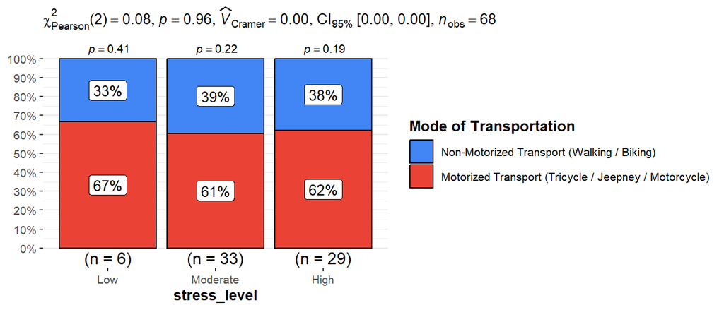

Figure 1: Bar chart and test statistics.

```r
ggbarstats(
  data = df,
  x = travel_mode,
  y = stress_level,
  type="nonparametric",
  bf.message = FALSE,
  legend.title = "Mode of Transportation"
)
```

Based on the bar chart and the $p$-value being greater than 5% ($p = 0.96$), we fail to reject the null hypothesis. There is insufficient evidence to conclude that students’ mode of transportation affects their level of stress.